# 200406_Titanic_3번째노트북_필사1회

### Titanic Top 4% with ensemble modeling

https://www.kaggle.com/yassineghouzam/titanic-top-4-with-ensemble-modeling

### **Yassine Ghouzam, PhD**

#### 13/07/2017

- **1 Introduction**
- **2 Load and check data**
  - 2.1 load data
  - 2.2 Outlier detection
  - 2.3 joining train and test set
  - 2.4 check for null and missing values
- **3 Feature analysis**
  - 3.1 Numerical values
  - 3.2 Categorical values
- **4 Filling missing Values**
  - 4.1 Age
- **5 Feature engineering**
  - 5.1 Name/Title
  - 5.2 Family Size
  - 5.3 Cabin
  - 5.4 Ticket
- **6 Modeling**
  - 6.1 Simple modeling
    - 6.1.1 Cross validate models
    - 6.1.2 Hyperparamater tunning for best models
    - 6.1.3 Plot learning curves
    - 6.1.4 Feature importance of the tree based classifiers
  - 6.2 Ensemble modeling
    - 6.2.1 Combining models
  - 6.3 Prediction
    - 6.3.1 Predict and Submit results

컴퓨터 키는 영상 . 부팅하는 영상. 키보드 ㅌ치는 영상등으로 초반 인트로에 좀 컴터좀 키고 공부좀 합시다라는 격려영상을 만들어보자.

## 1. Introduction

라이브러리 로드를 합니다. 기본적으로 판다스, 넘파이, 맷플랏립과 시본을 로드해서 데이터와 시각화를 위한 라이브러리를 임폴트합니다.

다음으로 모델링을 위한 라이브러리들을 미리 임폴트합니다. 아래 9행에서 15행까지는 전부 모델링이고 모델링 파트에서 설명하도록 하겠습니다.

마지막으로 모델을 검증하고 모델의 하이퍼파라미터를 튜닝하고 정확도를 판단하기 위한 라이브러리들을 임폴트합니다.

하지막줄은 시본으로 그린 시각화플랏들에 대한 스타일을 지정하는 줄입니다. 일단 이번에는 넘어가도록 합시다

```python
import pandas as pd
import numpy as np
import matplotlib.pyplot as plt
import seaborn as sns
%matplotlib inline

from collections import Counter

from sklearn.ensemble import RandomForestClassifier, AdaBoostClassifier,
                              GradientBoostingClassifier, ExtraTreesClassifier, VotingClassifier
from sklearn.discriminant_analysis import LinearDiscriminantAnalysis
from sklearn.linear_model import LogisticRegression
from sklearn.neighbors import KNeighborsClassifier
from sklearn.tree import DecisionTreeClassifier
from sklearn.neural_network import MLPClassifier
from sklearn.svm import SVC
from sklearn.model_selection import GridSearchCV, cross_val_score, StratifiedKFold, learning_curve

sns.set(style='white', context='notebook', palette='deep')
import warnings
warnings.filterwarnings('ignore')
```

## 2. Load and check data

### 2.1 Load data

상위 디렉토리는.. 상위의상위는. ...이고 그것의 하위 디렉은 ../으로 표현해주시면 됩니다.

IDtest는 나중에 전체 데이터셋에서 test만의 결과값을 가져오기 위해 미리 떼어놨습니다. test라는 dataframe의 일정 컬럼은 아래와 같이 [] 로 표현하면 됩니다. 행선택 열(컬럼, feature)선택이 좀 헷갈리지만 익숙해질때까지 직접 해보십시다,,,,

```python
train = pd.read_csv('./input/train.csv')
test = pd.read_csv('./input/test.csv')
IDtest = test['PassengerId']
```

### 2.2 Outlier detection

위에서 데이터를 불러들였으면 원래는 하나하나 탐색을 해봐야하겠지만 이 노트북은 약간 좀 이미 여러번 탐색을 한 사용자에 대한 노트북이라서 미리 이상치를 제거하는 함수를 구현합니다.

일일이 아웃라이어의 행을 찾아서 없에도 될정도로 수가 작긴하지만 나중에도 이렇게 일일이 한다면 마치 아이폰으로 통화나 하는 꼴이겠죠? detect_ouliers라는 함수를 만들어서 아웃라이어의 행의 index를 저장하여 return 하겠습니다.

아웃라이어(이상치)는 예측에 많은 영향을 끼칩니다.

이 노트북에서는 Tukey method (Tukey JW., 1977) 사분할 영역에서 첫째, 셋째 사이의 구간을 IQR로 지정하고 이 구간 바깥영역을 아웃라이어로 간주합니다. 또한 n이라는 parameter를 받아서 n개의 feature에서 이상치가 된다면 그 때 이상치에 해당하는 행으로 추가합니다.

```python
# Outlier detection

def detect_outliers(df,n,features):
    """
    Takes a dataframe df of features and returns a list of the indices
    corresponding to the observations containing more than n outliers according
    to the Tukey method.
    """
    outlier_indices = []

    # iterate over features(columns)
    for col in features:
        # 1st quartile (25%)
        Q1 = np.percentile(df[col], 25)
        # 3rd quartile (75%)
        Q3 = np.percentile(df[col],75)
        # Interquartile range (IQR)
        IQR = Q3 - Q1

        # outlier step
        outlier_step = 1.5 * IQR

        # Determine a list of indices of outliers for feature col
        outlier_list_col = df[(df[col] < Q1 - outlier_step) | (df[col] > Q3 + outlier_step )].index

        # append the found outlier indices for col to the list of outlier indices
        outlier_indices.extend(outlier_list_col)

    # select observations containing more than 2 outliers
    outlier_indices = Counter(outlier_indices)
    print(outlier_indices)
    multiple_outliers = list( k for k, v in outlier_indices.items() if v > n )

    return multiple_outliers

# detect outliers from Age, SibSp , Parch and Fare
Outliers_to_drop = detect_outliers(train,2,["Age","SibSp","Parch","Fare"])
```

```
Counter({27: 3, 88: 3, 159: 3, 180: 3, 201: 3, 324: 3, 341: 3, 792: 3, 846: 3, 863: 3, 7: 2, 16: 2, 24: 2, 50: 2, 59: 2, 63: 2, 68: 2, 71: 2, 119: 2, 164: 2, 171: 2, 176: 2, 182: 2, 229: 2, 233: 2, 261: 2, 266: 2, 278: 2, 374: 2, 386: 2, 409: 2, 480: 2, 485: 2, 541: 2, 542: 2, 634: 2, 642: 2, 683: 2…
```

```python
train.loc[Outliers_to_drop]
```

|  | PassengerId | Survived | Pclass | Name | Sex | Age | SibSp | Parch | Ticket | Fare | Cabin | Embarked |
| --- | --- | --- | --- | --- | --- | --- | --- | --- | --- | --- | --- | --- |
| 27 | 28 | 0 | 1 | Fortune, Mr. Charles Alexander | male | 19.0 | 3 | 2 | 19950 | 263.00 | C23 C25 C27 | S |
| 88 | 89 | 1 | 1 | Fortune, Miss. Mabel Helen | female | 23.0 | 3 | 2 | 19950 | 263.00 | C23 C25 C27 | S |
| 159 | 160 | 0 | 3 | Sage, Master. Thomas Henry | male | NaN | 8 | 2 | CA. 2343 | 69.55 | NaN | S |
| 180 | 181 | 0 | 3 | Sage, Miss. Constance Gladys | female | NaN | 8 | 2 | CA. 2343 | 69.55 | NaN | S |
| 201 | 202 | 0 | 3 | Sage, Mr. Frederick | male | NaN | 8 | 2 | CA. 2343 | 69.55 | NaN | S |
| 324 | 325 | 0 | 3 | Sage, Mr. George John Jr | male | NaN | 8 | 2 | CA. 2343 | 69.55 | NaN | S |
| 341 | 342 | 1 | 1 | Fortune, Miss. Alice Elizabeth | female | 24.0 | 3 | 2 | 19950 | 263.00 | C23 C25 C27 | S |
| 792 | 793 | 0 | 3 | Sage, Miss. Stella Anna | female | NaN | 8 | 2 | CA. 2343 | 69.55 | NaN | S |
| 846 | 847 | 0 | 3 | Sage, Mr. Douglas Bullen | male | NaN | 8 | 2 | CA. 2343 | 69.55 | NaN | S |
| 863 | 864 | 0 | 3 | Sage, Miss. Dorothy Edith "Dolly" | female | NaN | 8 | 2 | CA. 2343 | 69.55 | NaN | S |

위와 같이 10개의 아웃라이어가 감지되었습니다. 3개는 Ticket 가격이 매우 높고 나머지 7개는 SibSp가 높아서 아웃라이어로 지정되었네요 아래와 같이 drop 함수로 해당 행을 drop시키겠습니다. Outliers_to_drop과 axis를 지정하여 drop을 합니다. train 변수로 재할당하지않으면 결과만보여주고 실제로는 변화가 없으니 아래와 같이 변수를 할당해주거나 inplace=True로 파라미터를 추가해줍니다. reset_index로 지운 행을 제외한 index를 다시 순서대로 해주고 drop=True를 통해 기존인덱스를 행으로 추가하지 않게합니다. (일반적으로 true로 하는 일이 많으니 기억해주세요

```python
# Drop outliers
train = train.drop(Outliers_to_drop, axis=0).reset_index(drop=True)
```

### 2.3 joining train and test set

다으믕로는 train과 test를 합치려고 합니다. EDA를 통해 feature engineering을 할때 한쪽만 해주게 되면 test set에 또 한번 더 해줘야 해서 미리 합쳐놓고 한번에 처리를 하려고 합니다. 그래서 아까 passengerId를 뽑아놨었져

dataframe을 합치는데에는 여러가지 메쏘드가 있는데 주로 concat, merge, join입니다.  
아래 링크에서 학습하시면 될것 같고,concat과 merge만 잘알고 쓰셔도 충분할거라고 생각합니다.  
concat에 대한 것은 따로 설명해보도록 하겠습니다.  
여기서는 concat 메소드를 사용하였고 axis=0으로 동일 feature에 맞게 합치게 하였습니다.  
test에는 Survived가 없으므로 Nan으로 나오고 나머지는 잘붙습니다.  
https://pandas.pydata.org/pandas-docs/stable/user_guide/merging.html

```python
train_len = len(train)
dataset = pd.concat(objs=[train,test],axis=0).reset_index(drop=True)
```

### 2.4 check for null and missing values

다음은 누락값에 대한 처리입니다. 누락값들이 몇개 되지 않으면 그냥 없에버려도 되겠지만 상당히 많은 량을 차지한다면 대표값으로 넣는다든지 아니면 다른 feature를 참고하여 각 그룹의 대표값을 넣을 수도 있고 다양한 처리를 할 수 있을 것입니다.

그래서 이번엔 누락값이 어느정도 되는 지 일단 확인해보고 누락값의 처리는 어떻게 할지 알아보겠습니다.

아래와 같이 일단 빈 칸들을 fillna 메소드를 이용해 NaN(np.nan으로 채워야 pandas에서 인식하는 NaN으로 채워집니다.)

isnull()을하면 null이면 True, 아니면 False로 각 값들이 대체되는데 이것들을 sum()메소드로 총 합의 요약을 봅시다.

```python
# Fill empty and NaNs values with NaN
dataset = dataset.fillna(np.nan)

# Check for Null values
dataset.isnull().sum()
```

```
Age             256
Cabin          1007
Embarked          2
Fare              1
Name              0
Parch             0
PassengerId       0
Pclass            0
Sex               0
SibSp             0
Survived        418
Ticket            0
dtype: int64
```

Embarked는 2개뿐이 안되지만 Age와 Cabin은 상당히 많은 수가 누락이네요.

Survived는 test 데이터셋의 길이와 같을 겁니다.

train만 본다고 하면 아래와 같겠네요.

```python
train.info()
train.isnull().sum()
```

```
<class 'pandas.core.frame.DataFrame'>
RangeIndex: 881 entries, 0 to 880
Data columns (total 12 columns):
PassengerId    881 non-null int64
Survived       881 non-null int64
Pclass         881 non-null int64
Name           881 non-null object
Sex            881 non-null object
Age            711 non-null float64
SibSp          881 non-null int64
Parch          881 non-null int64
Ticket         881 non-null object
Fare           881 non-null float64
Cabin          201 non-null object
Embarked       879 non-null object
dtypes: float64(2), int64(5), object(5)
memory usage: 82.7+ KB
```

```
PassengerId      0
Survived         0
Pclass           0
Name             0
Sex              0
Age            170
SibSp            0
Parch            0
Ticket           0
Fare             0
Cabin          680
Embarked         2
dtype: int64
```

Age와 Cabin feature에 NaN값이 꽤 있습니다. 이를 어떻게 처리해 주는가가 예측에 큰영향이 있을 것으로 보입니다. 각 데이터들이 어떤히 훑어봅시다. head, dtypes, describe를 통해 전체 feature들, 데이터 타입, 그리고연속형데이터의 통계값을 확인합니다.

```python
train.head()
```

|  | PassengerId | Survived | Pclass | Name | Sex | Age | SibSp | Parch | Ticket | Fare | Cabin | Embarked |
| --- | --- | --- | --- | --- | --- | --- | --- | --- | --- | --- | --- | --- |
| 0 | 1 | 0 | 3 | Braund, Mr. Owen Harris | male | 22.0 | 1 | 0 | A/5 21171 | 7.2500 | NaN | S |
| 1 | 2 | 1 | 1 | Cumings, Mrs. John Bradley (Florence Briggs Th... | female | 38.0 | 1 | 0 | PC 17599 | 71.2833 | C85 | C |
| 2 | 3 | 1 | 3 | Heikkinen, Miss. Laina | female | 26.0 | 0 | 0 | STON/O2. 3101282 | 7.9250 | NaN | S |
| 3 | 4 | 1 | 1 | Futrelle, Mrs. Jacques Heath (Lily May Peel) | female | 35.0 | 1 | 0 | 113803 | 53.1000 | C123 | S |
| 4 | 5 | 0 | 3 | Allen, Mr. William Henry | male | 35.0 | 0 | 0 | 373450 | 8.0500 | NaN | S |

```python
train.dtypes
```

```
PassengerId      int64
Survived         int64
Pclass           int64
Name            object
Sex             object
Age            float64
SibSp            int64
Parch            int64
Ticket          object
Fare           float64
Cabin           object
Embarked        object
dtype: object
```

```python
train.describe()
```

|  | PassengerId | Survived | Pclass | Age | SibSp | Parch | Fare |
| --- | --- | --- | --- | --- | --- | --- | --- |
| count | 881.000000 | 881.000000 | 881.000000 | 711.000000 | 881.000000 | 881.000000 | 881.000000 |
| mean | 446.713961 | 0.385925 | 2.307605 | 29.731603 | 0.455165 | 0.363224 | 31.121566 |
| std | 256.617021 | 0.487090 | 0.835055 | 14.547835 | 0.871571 | 0.791839 | 47.996249 |
| min | 1.000000 | 0.000000 | 1.000000 | 0.420000 | 0.000000 | 0.000000 | 0.000000 |
| 25% | 226.000000 | 0.000000 | 2.000000 | 20.250000 | 0.000000 | 0.000000 | 7.895800 |
| 50% | 448.000000 | 0.000000 | 3.000000 | 28.000000 | 0.000000 | 0.000000 | 14.454200 |
| 75% | 668.000000 | 1.000000 | 3.000000 | 38.000000 | 1.000000 | 0.000000 | 30.500000 |
| max | 891.000000 | 1.000000 | 3.000000 | 80.000000 | 5.000000 | 6.000000 | 512.329200 |

## 3. Feature analysis

### 3.1 Numerical values

이제 각 feature들이 어떤게 분포해있는지, 서로 어떻게 관련이 있는지 feature anlysis를 통해 알아보십시돠.  
처음으로 연속형 값들을 봐볼건데 제일 먼저 볼거는 survived와의 관계를 보려고 합니다.  
correlation 값을 뽑아서 survived와의 관계성을 간단하게 살펴볼건데 이때는 시본의 heatmap이 좋습니다.

heatmap의 파라미터로는 2차원의 dataframe, annot는 각 타일마단의 값을넣어주고, fmt는 숫자의 자리수, cmap은 heatmap의 단계를 구분하는 colormap의 종류를 말합니다. 아래와 같이 간단하게 heatmap을 그려봅시다. dataframe의 corr메소드는 columns중 연속형데이터에 대해서만 correlation값을 뽀바주는 메소드입니다. 살펴볼까여?

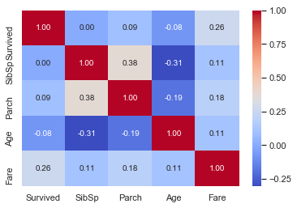

```python
g = sns.heatmap(train[["Survived","SibSp","Parch","Age","Fare"]].corr(),annot=True, fmt = ".2f", cmap = "coolwarm", )
# vmax=xx, vmin=xx 옵션으로 colorbar scale 조정가능
```

Fare가 0.26으로 걔중에는 그나마 Survived와 상관성이 제일 높긴한데... 0.26은 낮긴났습니다..

나머지들은 거의 10% 수준에 머무르는데 그것이 절대 예측에 쓸모없다는 것은 아닙니다. 각각의 feature들을 탐색하면서 어떻게 관계가 있을지 살펴보도록 할게요.

#### SibSP

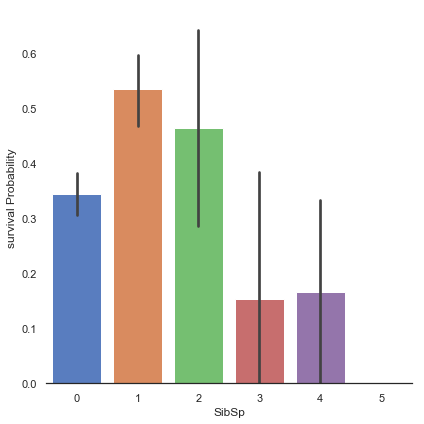

```python
# Explore SibSp feature vs Survived
g = sns.factorplot(x='SibSp',y='Survived',data=train, kind='bar',
                   size=6,palette='muted')
g.despine(left=True)
g = g.set_ylabels('survival Probability')
```

그래프를 해석해보면 SibSp가 크면 즉 가족단위가 크면 생존확률이 적어보이네요. 함께움직여야해서 다같이 살지 못했을 수도 있겠습니다. SibSP가 1~2인까지 SibSp가 있는 승객이 좀 더 생존확률이 높아보인다.  
그와중에 1-2인까지는 서로 더 끈끈하게 챙겨줘서 생존률이 높고 0명인 솔로승객은 혼자 살아남기위해 고군분투하느라 생존률이 좀 낮을수도 있을 거같습니다. 이 결과는 꽤 흥미롭네요. 이를 카테고리 데이터로의 변환으로 engineering해서 모델에 적용하겠습니다.

#### Parch

- 부모와 자식의 수를 나타내는 Parch를 알아보겠습니다. 동일하게 factorplot으로 알아볼거고요. 아까말하지 못했던 factorplot의 장점은 seaborn 자체로 feature의 값에 따라 다른feature들이 어떻게 바뀌는지 알수 있습니다. 예를 들면 생존자의 parch와 사망자의 parch의 분포를 보고 싶을때는 col='Survived'를 넣으면 따로 plot이됩니다.

아래는 일단 전체parch의 생존률을 확인하고자 해보도록 하겠습니다.

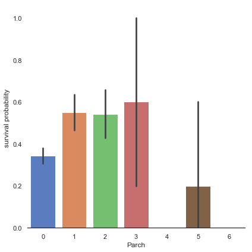

```python
# Explore Parch feature vs Survived
g= sns.factorplot(x ='Parch',y='Survived',data=train,kind='bar',size=6,palette='muted')
g.despine(left=True)
g = g.set_ylabels('survival probability')
```

아까 SibSP와 마찬가지로 작은 가족단위인 Parch가 1-3일때가 4-6보다 높습니다.  
대신에 3인가족의 표준편차가 좀 크긴하네요. 일단 확인하고 넘어갑시다.

#### Age

나이는 딱봐도 중요한 요인일거 같습니다. 좀 젊을때 더 생존률이 높고 나이가 많으면 줄어 들것 같은데 실제로도 그럴까요?  
실제로는 달랐습니다. 아래의 facetgrid를 보시죠 col에 Survived를 넣어 Survuved에 따른 Histogra을 볼 수 있습니다. facetgrid사용은 일단 dataset과 col만 지정하고 거기에 map메소드로 어떤 그림을 그리고 아까위에서 정한 col을 어떤 feature에 따른 plot을 할건지 지정하는 2단계로 나뉘어져 있습니다.

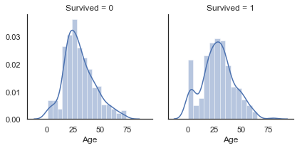

```python
# Explore Age vs Survived
g = sns.FacetGrid(train, col='Survived')
g = g.map(sns.distplot, "Age")
```

나이분포는 가우시안 분포로 보입니다. 위의 plot을 통해서 생존자의 나이분포와 사망자의 생존분포에 차이가 있다는 것을 확인 할 수 있습니다. 고령자 60-80의 생존률이 낮고 어린 승객의 생존력이 높음을 알수 있습니다.

그래서 Age가 Survived와의 상관성이 없어 보여도 Age를 카테고리화하면 생존력에 대해 좀 더 예측이 좋아질 것으로 보인다. 선형성이 없으면 corr도 낮게 보이니까 이렇게 분포를 보이는 것에 대해서는 카테고리화가 도움이 될것으로 보입니다.

두개의 plot을 겹쳐볼까요. kdeplot는 커널밀도 추정값을 피팅하고 plotting 하는 함수입니다. 아래에 보면 data parameter에 좀 복잡한 방법으로 들어가있네요.  
천천히 보면 Survived가 0이고 null이 아닌 값이 들어있는 Age 컬럼의 값들을 붉은색으로... Survived가 1이고 null이 아닌 값이 들어있는 Age를 파랑으로 했습니다. 조건을 늘리고 싶으면 &를 늘리면 되겠죠. or은 참고로 |입니다. \이랑 같이있는 놈입니다. legend는 범례입니다.

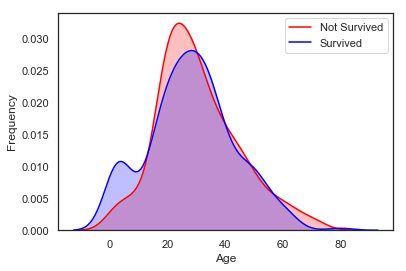

```python
g = sns.kdeplot(train['Age'][(train['Survived']==0)& (train['Age'].notnull())], color='Red',shade=True)
g = sns.kdeplot(train["Age"][(train['Survived']==1)& (train['Age'].notnull())], ax =g, color='Blue', shade=True)
g.set_xlabel('Age')
g.set_ylabel('Frequency')
g = g.legend(['Not Survived','Survived'])
```

Survive에 따른 확률밀도분포를 보면 0-5세사이, 60-80세 사이의 분포가 다름을 확인할 수 있습니다.

#### Fare

가격의 null값의 수를 볼까요.

```python
dataset['Fare'].isnull().sum()
```

```
1
```

널값은 한개입니다. 그래서 그냥 Fare의 median값으로 채워줍시다. fillna() 메소드에 채우고자 하는 값으로 parameter를 넣어주면 됩니다.

```python
#Fill Fare missing values with the median value
dataset['Fare'] = dataset['Fare'].fillna(dataset["Fare"].median())
```

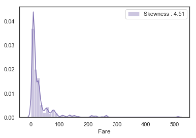

```python
# Explore Fare distribution
g = sns.distplot(dataset['Fare'], color='m', label='Skewness : %.2f'%(dataset["Fare"].skew()))
g = g.legend(loc='best')
```

Fare feature는 매우 skew가 높은 분포를 보입니다. skew가 매우 크다는 것은 매우 불균형한 분포를 보이고 있다는 뜻이고 이렇게 불균일한 데이터 분포는 추후에 예측이 잘되지 않게 됩니다. 데이터에 아주 고액의 Fare가 존재하여 scale을 변경하여도 큰 영향을 끼칠 것으로 보인다. 그래서 Fare feature는 skewness를 줄이고 정규분포에 가깝게 하기위해 feature engineering이 필요합니다. 보통 2가지 방법을 많이 사용하는데 첫째는 log를 취하는거고 두번째는 box-cox라느 방법입니다. 여기서는 log로 정규분포로 변환이 될 수 있게 해보겠습니다.

map 메소드를 사용하면 한개 column에 동시에 함수를 적용할 수 있습니다. 간단한 +-/%는 구지 map이나 apply를 사용하지 않아도 되지만 조금복잡하게 되면 함수를 따로 만들어 map을 하거나 그것보다는 간단하면 map안에 lambda로 직접 넣어주셔도 됩니다.

```python
dataset['Fare'] = dataset['Fare'].map(lambda i: np.log(i) if i > 0 else 0)
```

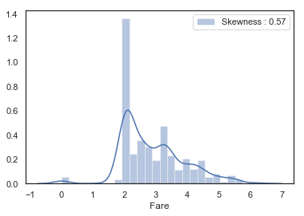

```python
g = sns.distplot(dataset['Fare'],color = 'b', label='Skewness : %.2f'%(dataset['Fare'].skew()))
g = g.legend(loc='best')
```

skewness가 4.51에서 0.57로 낮아졌다.

### 3.2 Categorical values

#### Sex

이제 카테고리형 값들에 대해 탐색을 해보십시돠. 첫번쨰로 성별을 확인해볼텐데 알고 있든이 레이디 펄스트에 어린이 펄스트였던 타이타닉 영화와 같이 여성의 생존률이 훨씬 높습니다. 실제로 그런지 barplot을 그려보시죠.

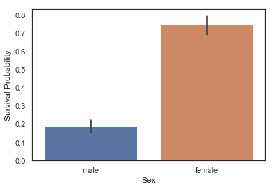

```python
g = sns.barplot(x='Sex',y='Survived',data=train)
g = g.set_ylabel('Survival Probability')
```

```python
train[['Sex','Survived']].groupby('Sex').mean()
```

| Sex | Survived |
| --- | --- |
| female | 0.747573 |
| male | 0.190559 |

#### Pclass

Pclass는 좌석의 등급을 나타냅니다.  
뇌피셜을 돌려보면 1등급 승객이 3등급승객보다 생존률이 높겠지요? 아래의 factorplot으로 확인해봅시다.

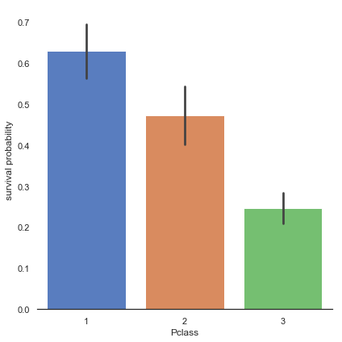

```python
g = sns.factorplot(x='Pclass',y='Survived',data=train, kind='bar',size=6, palette='muted')
g.despine(left=True)
g = g.set_ylabels('survival probability')
```

역시 1등급의 생존률이 60%를 넘는데에 비해 3등급은 25%정도로 절반도 안됩니다. Pclass와 성별을 같이 플랏해봅시다. 아래와 같이 factorplot으로 x는 pclass y는 생존률. hue에 Sex를 넣습니다. 아예 plot을 구분짓고 싶을때는 col에... 한 plot내에 서 구분짓고 싶을때에는 hue에 넣으면 색으로 구분을 할 수 있습니다. hue같은 경우에는 cmap파라미터를 지정하면 연속형 colormap과 구분형 colomap에 따라 색을 지정할 수 있습니다.

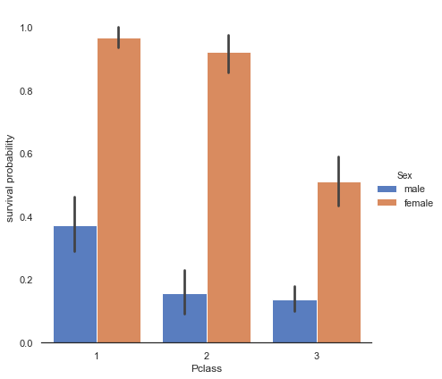

```python
g = sns.factorplot(x='Pclass', y='Survived', hue='Sex', data=train,  size=6, kind='bar', palette='muted')
g.despine(left=True)
g = g.set_ylabels('survival probability')
```

남녀모두 class에 따른 생존률의 트렌드는 유지되고 있습니다. 특이점으로는 1, 2등급의 여성의 생존률이 비슷한데 비해 2, 3등급의 남성의 생존률이 비슷하네요.

#### Embarked

```python
dataset['Embarked'].isnull().sum()
```

```
2
```

탑승항구인 Embarked의 null값 수는 2개 뿐이 안됩니다. 제일 자주 많이 나온값인 'S'로 채워넣읍니다.

```python
dataset['Embarked'] = dataset['Embarked'].fillna('S')
```

위에서 Pclass와 생존률을 봤듯이 이번에는 Embarked와 생존률의 관계를 봅시다.

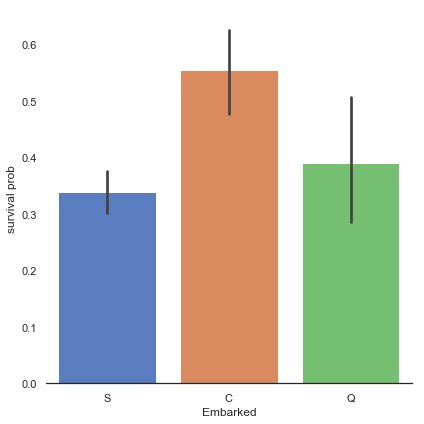

```python
g= sns.factorplot(x='Embarked',y='Survived',data=train, size=6, kind='bar',palette='muted')
g.despine(left=True)
g = g.set_ylabels('survival prob')
```

S, C, Q라는 항구에 따라서 생존률이 갈리네요. 혹시 항구에 따라 탑승객의 종류가 갈릴수도 있으니 Pclass와도 비교해보겠습니다. 아까 말했던 col 파라미터를 이용해서 Embarked 종류별 Pclass생존률을 kind=count로 봅시다.

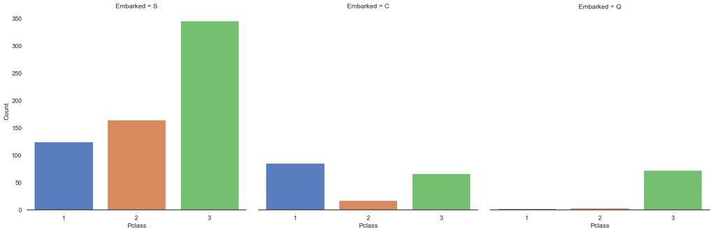

```python
g = sns.factorplot('Pclass', col='Embarked', data=train, size=6, kind='count', palette='muted')
g.despine(left=True)
g = g.set_ylabels('Count')
```

보아하니 1등급의 비율이 C항에서 제일 큽니다. 그래서 생존률이 높나보네요.

## 4. Filling missing Values

### 4.1 Age

전에 확인했든이 Age featrue는 256개 행이 값이 없습니다. 나이대에 따라 생존확률이 다르기 때문에 Age feature의 결측치는 살려두는 것이 좋을 듯합니다.

Age의 값을 추정하기 위해 Sex, Parch, Pclass, SibSp와의 상관관계를 확인해보겠습니다.

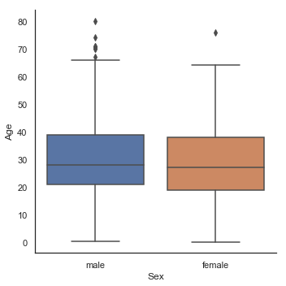

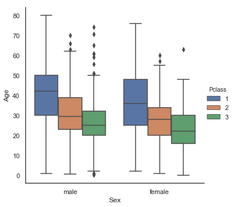

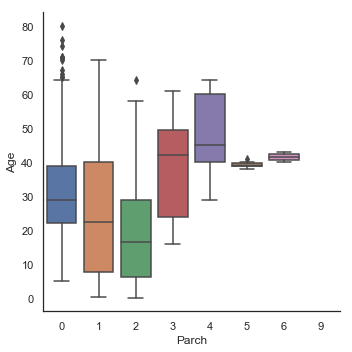

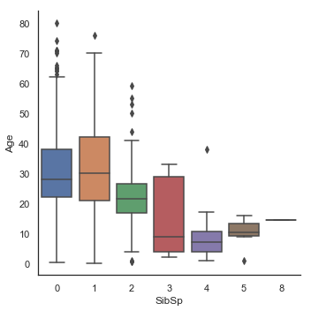

```python
g = sns.factorplot(y='Age', x='Sex', data=dataset, kind='box')
g = sns.factorplot(y='Age', x='Sex', hue='Pclass', data=dataset, kind='box')
g = sns.factorplot(y='Age', x='Parch', data=dataset, kind='box')
g = sns.factorplot(y='Age', x='SibSp', data=dataset, kind='box')
```

- Age의 분포는 남녀가 비슷해 보입니다. 그래서 성별은 그닥 나이예측에 도움이 될것 같진 않아 보이네요.
- 그런데 1등석 승객이 2등석 승객보다 나이가 많고 3등석보다는 또 나이가 많습니다.
- 게다가 Parch가 클수록 나이가 많고 SibSp가 많을수록 어린것으로 보입니다.
- 그래서 Pclass, Parch, SibSP는 Age를 예측하는 중요한 정보로 생각이 듭니다.

```python
# convert Sex into categorical value 0 for male and 1 for female
dataset['Sex'] = dataset["Sex"].map({'male':0, 'female':1})
```

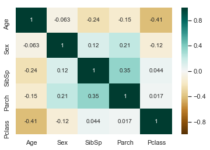

```python
g = sns.heatmap(dataset[['Age','Sex','SibSp','Parch','Pclass']].corr(), cmap="BrBG", annot=True, vmin=-1, vmax=1)
```

상관관계 Map도 아까의 결론과 비슷한 결과를 나타내고 있습니다. 성별에는 큰 상관성이 없고 Pclass와는 어느정도 음의 상관관계를, Parch, SibSp와도 약한 음의 상관관계를 가집니다.

그래서 이 세가지로 Age를 예측하여 채워넣겠습니다.

index_NaN_age에 Age가 NaN값인 index를 리스트로 저장해 놓습니다.

```python
# Filling missing value of Age

## Fill Age with the median age of similar rows according to Pclass, Parch and SibSp
# Index of NaN age rows
index_NaN_age = list(dataset['Age'][dataset["Age"].isnull()].index)
```

for문으로 i index의 SibSP, Parch Pclass가 다 같은 Age의 median을 할당하되 셋다 동시에 만족하는 것이 없으면 전체 Age의 중심값으로 채웁니다.

```python
for i in index_NaN_age:
    age_med = dataset["Age"].median()
    age_pred = dataset["Age"][((dataset['SibSp'] == dataset.iloc[i]["SibSp"])
                               & (dataset['Parch'] == dataset.iloc[i]['Parch'])
                               & (dataset['Pclass']== dataset.iloc[i]["Pclass"]))].median()
    if not np.isnan(age_pred):
        dataset['Age'].iloc[i] = age_pred
    else:
        dataset['Age'].iloc[i] = age_med
```

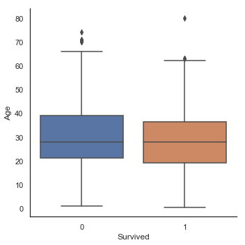

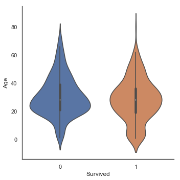

```python
g = sns.factorplot(x='Survived',y='Age', data=train, kind='box')
g = sns.factorplot(x='Survived',y='Age', data=train, kind='violin')
```

생존률에 따른 전체 중심치는 여전히 비슷해보이는 것 같쥬?. 그러나 나이대별 바이올린 플랏으로 보면 어린나이대의 생존이 여전히 높은 것을 볼수 있습니다.